# Risk Factor Analysis

## Outcome Variable

**Outcome Variable:** ever_wasted

## Predictor Variables

**Intervention Variable:** feducyrs

**Adjustment Set:**

- arm
- W_mage
- meducyrs
- hhwealth_quart
- W_mhtcm
- W_gagebrth
- W_birthwt
- W_birthlen
- W_nrooms
- W_nchldlt5
- impfloor
- impsan
- safeh20
- delta_W_mage
- delta_meducyrs
- delta_hhwealth_quart
- delta_W_mhtcm
- delta_W_gagebrth
- delta_W_birthwt
- delta_W_birthlen
- delta_W_nrooms
- delta_W_nchldlt5
- delta_impfloor
- delta_impsan
- delta_safeh20

## Stratifying Variables

The analysis was stratified on these variable(s):

- agecat
- studyid
- country

## Data Summary

| agecat | studyid | country | feducyrs | ever_wasted | n_cell | n |
| --- | --- | --- | --- | --- | --- | --- |
| 0-24 months | ki0047075b-MAL-ED | BANGLADESH | Low | 0 | 23 | 147 |
| 0-24 months | ki0047075b-MAL-ED | BANGLADESH | Low | 1 | 16 | 147 |
| 0-24 months | ki0047075b-MAL-ED | BANGLADESH | Medium | 0 | 36 | 147 |
| 0-24 months | ki0047075b-MAL-ED | BANGLADESH | Medium | 1 | 18 | 147 |
| 0-24 months | ki0047075b-MAL-ED | BANGLADESH | High | 0 | 41 | 147 |
| 0-24 months | ki0047075b-MAL-ED | BANGLADESH | High | 1 | 13 | 147 |
| 0-24 months | ki0047075b-MAL-ED | INDIA | Low | 0 | 28 | 147 |
| 0-24 months | ki0047075b-MAL-ED | INDIA | Low | 1 | 31 | 147 |
| 0-24 months | ki0047075b-MAL-ED | INDIA | Medium | 0 | 27 | 147 |
| 0-24 months | ki0047075b-MAL-ED | INDIA | Medium | 1 | 17 | 147 |
| 0-24 months | ki0047075b-MAL-ED | INDIA | High | 0 | 22 | 147 |
| 0-24 months | ki0047075b-MAL-ED | INDIA | High | 1 | 22 | 147 |
| 0-24 months | ki0047075b-MAL-ED | NEPAL | Low | 0 | 18 | 98 |
| 0-24 months | ki0047075b-MAL-ED | NEPAL | Low | 1 | 10 | 98 |
| 0-24 months | ki0047075b-MAL-ED | NEPAL | Medium | 0 | 19 | 98 |
| 0-24 months | ki0047075b-MAL-ED | NEPAL | Medium | 1 | 9 | 98 |
| 0-24 months | ki0047075b-MAL-ED | NEPAL | High | 0 | 32 | 98 |
| 0-24 months | ki0047075b-MAL-ED | NEPAL | High | 1 | 10 | 98 |
| 0-24 months | ki0047075b-MAL-ED | PERU | Low | 0 | 65 | 250 |
| 0-24 months | ki0047075b-MAL-ED | PERU | Low | 1 | 4 | 250 |
| 0-24 months | ki0047075b-MAL-ED | PERU | Medium | 0 | 54 | 250 |
| 0-24 months | ki0047075b-MAL-ED | PERU | Medium | 1 | 7 | 250 |
| 0-24 months | ki0047075b-MAL-ED | PERU | High | 0 | 112 | 250 |
| 0-24 months | ki0047075b-MAL-ED | PERU | High | 1 | 8 | 250 |
| 0-24 months | ki0047075b-MAL-ED | SOUTH AFRICA | Low | 0 | 30 | 110 |
| 0-24 months | ki0047075b-MAL-ED | SOUTH AFRICA | Low | 1 | 7 | 110 |
| 0-24 months | ki0047075b-MAL-ED | SOUTH AFRICA | Medium | 0 | 23 | 110 |
| 0-24 months | ki0047075b-MAL-ED | SOUTH AFRICA | Medium | 1 | 7 | 110 |
| 0-24 months | ki0047075b-MAL-ED | SOUTH AFRICA | High | 0 | 36 | 110 |
| 0-24 months | ki0047075b-MAL-ED | SOUTH AFRICA | High | 1 | 7 | 110 |

[output cut: 330 more lines]

The following strata were considered:

- agecat: 0-24 months, studyid: ki0047075b-MAL-ED, country: BANGLADESH
- agecat: 0-24 months, studyid: ki0047075b-MAL-ED, country: INDIA
- agecat: 0-24 months, studyid: ki0047075b-MAL-ED, country: NEPAL
- agecat: 0-24 months, studyid: ki0047075b-MAL-ED, country: PERU
- agecat: 0-24 months, studyid: ki0047075b-MAL-ED, country: SOUTH AFRICA
- agecat: 0-24 months, studyid: ki0047075b-MAL-ED, country: TANZANIA, UNITED REPUBLIC OF
- agecat: 0-24 months, studyid: ki1000304b-SAS-CompFeed, country: INDIA
- agecat: 0-24 months, studyid: ki1000304b-SAS-FoodSuppl, country: INDIA
- agecat: 0-24 months, studyid: ki1017093b-PROVIDE, country: BANGLADESH
- agecat: 0-24 months, studyid: ki1017093c-NIH-Crypto, country: BANGLADESH
- agecat: 0-24 months, studyid: ki1066203-TanzaniaChild2, country: TANZANIA, UNITED REPUBLIC OF
- agecat: 0-24 months, studyid: ki1113344-GMS-Nepal, country: NEPAL
- agecat: 0-24 months, studyid: ki1119695-PROBIT, country: BELARUS
- agecat: 0-24 months, studyid: ki1126311-ZVITAMBO, country: ZIMBABWE
- agecat: 0-24 months, studyid: ki1135781-COHORTS, country: GUATEMALA
- agecat: 0-24 months, studyid: ki1135781-COHORTS, country: INDIA
- agecat: 0-24 months, studyid: ki1135781-COHORTS, country: PHILIPPINES
- agecat: 0-24 months, studyid: ki1148112-LCNI-5, country: MALAWI
- agecat: 0-24 months, studyid: kiGH5241-JiVitA-3, country: BANGLADESH
- agecat: 0-24 months, studyid: kiGH5241-JiVitA-4, country: BANGLADESH
- agecat: 0-6 months, studyid: ki0047075b-MAL-ED, country: BANGLADESH
- agecat: 0-6 months, studyid: ki0047075b-MAL-ED, country: INDIA
- agecat: 0-6 months, studyid: ki0047075b-MAL-ED, country: NEPAL
- agecat: 0-6 months, studyid: ki0047075b-MAL-ED, country: PERU
- agecat: 0-6 months, studyid: ki0047075b-MAL-ED, country: SOUTH AFRICA
- agecat: 0-6 months, studyid: ki0047075b-MAL-ED, country: TANZANIA, UNITED REPUBLIC OF
- agecat: 0-6 months, studyid: ki1000304b-SAS-CompFeed, country: INDIA
- agecat: 0-6 months, studyid: ki1000304b-SAS-FoodSuppl, country: INDIA
- agecat: 0-6 months, studyid: ki1017093b-PROVIDE, country: BANGLADESH
- agecat: 0-6 months, studyid: ki1017093c-NIH-Crypto, country: BANGLADESH
- agecat: 0-6 months, studyid: ki1066203-TanzaniaChild2, country: TANZANIA, UNITED REPUBLIC OF
- agecat: 0-6 months, studyid: ki1113344-GMS-Nepal, country: NEPAL
- agecat: 0-6 months, studyid: ki1119695-PROBIT, country: BELARUS
- agecat: 0-6 months, studyid: ki1126311-ZVITAMBO, country: ZIMBABWE
- agecat: 0-6 months, studyid: ki1135781-COHORTS, country: GUATEMALA
- agecat: 0-6 months, studyid: ki1135781-COHORTS, country: INDIA
- agecat: 0-6 months, studyid: ki1135781-COHORTS, country: PHILIPPINES
- agecat: 0-6 months, studyid: ki1148112-LCNI-5, country: MALAWI
- agecat: 0-6 months, studyid: kiGH5241-JiVitA-3, country: BANGLADESH
- agecat: 0-6 months, studyid: kiGH5241-JiVitA-4, country: BANGLADESH
- agecat: 6-24 months, studyid: ki0047075b-MAL-ED, country: BANGLADESH
- agecat: 6-24 months, studyid: ki0047075b-MAL-ED, country: INDIA
- agecat: 6-24 months, studyid: ki0047075b-MAL-ED, country: NEPAL
- agecat: 6-24 months, studyid: ki0047075b-MAL-ED, country: PERU
- agecat: 6-24 months, studyid: ki0047075b-MAL-ED, country: SOUTH AFRICA
- agecat: 6-24 months, studyid: ki0047075b-MAL-ED, country: TANZANIA, UNITED REPUBLIC OF
- agecat: 6-24 months, studyid: ki1000304b-SAS-CompFeed, country: INDIA
- agecat: 6-24 months, studyid: ki1000304b-SAS-FoodSuppl, country: INDIA
- agecat: 6-24 months, studyid: ki1017093b-PROVIDE, country: BANGLADESH
- agecat: 6-24 months, studyid: ki1017093c-NIH-Crypto, country: BANGLADESH
- agecat: 6-24 months, studyid: ki1066203-TanzaniaChild2, country: TANZANIA, UNITED REPUBLIC OF
- agecat: 6-24 months, studyid: ki1113344-GMS-Nepal, country: NEPAL
- agecat: 6-24 months, studyid: ki1119695-PROBIT, country: BELARUS
- agecat: 6-24 months, studyid: ki1126311-ZVITAMBO, country: ZIMBABWE
- agecat: 6-24 months, studyid: ki1135781-COHORTS, country: GUATEMALA
- agecat: 6-24 months, studyid: ki1135781-COHORTS, country: INDIA
- agecat: 6-24 months, studyid: ki1135781-COHORTS, country: PHILIPPINES
- agecat: 6-24 months, studyid: ki1148112-LCNI-5, country: MALAWI
- agecat: 6-24 months, studyid: kiGH5241-JiVitA-3, country: BANGLADESH
- agecat: 6-24 months, studyid: kiGH5241-JiVitA-4, country: BANGLADESH

### Dropped Strata

Some strata were dropped due to rare outcomes:

- agecat: 0-24 months, studyid: ki0047075b-MAL-ED, country: PERU
- agecat: 0-24 months, studyid: ki0047075b-MAL-ED, country: TANZANIA, UNITED REPUBLIC OF
- agecat: 0-6 months, studyid: ki0047075b-MAL-ED, country: NEPAL
- agecat: 0-6 months, studyid: ki0047075b-MAL-ED, country: PERU
- agecat: 0-6 months, studyid: ki0047075b-MAL-ED, country: SOUTH AFRICA
- agecat: 0-6 months, studyid: ki0047075b-MAL-ED, country: TANZANIA, UNITED REPUBLIC OF
- agecat: 0-6 months, studyid: ki1148112-LCNI-5, country: MALAWI
- agecat: 6-24 months, studyid: ki0047075b-MAL-ED, country: NEPAL
- agecat: 6-24 months, studyid: ki0047075b-MAL-ED, country: PERU
- agecat: 6-24 months, studyid: ki0047075b-MAL-ED, country: SOUTH AFRICA
- agecat: 6-24 months, studyid: ki0047075b-MAL-ED, country: TANZANIA, UNITED REPUBLIC OF

## Methods Detail

We’re interested in the causal parameters $E[Y_a]$ for all values of $a \in \mathcal{A}$. These parameters represent the mean outcome if, possibly contrary to fact, we intervened to set all units to have $A=a$. Under the randomization and positivity assumptions, these are identified by the statistical parameters $\psi_a=E_W[E_{Y|A,W}(Y|A=a,W)]$. In addition, we’re interested in the mean of $Y$, $E[Y]$ under no intervention (the observed mean). We will estimate these parameters by using SuperLearner to fit the relevant likelihood factors – $E_{Y|A,W}(Y|A=a,W)$ and $p(A=a|W)$, and then updating our likelihood fit using a joint TMLE.

For unadjusted analyses ($W=\{\}$), initial likelihoods were estimated using Lrnr_glm to estimate the simple $E(Y|A)$ and Lrnr_mean to estimate $p(A)$. For adjusted analyses, a small library containing Lrnr_glmnet, Lrnr_xgboost, and Lrnr_mean was used.

Having estimated these parameters, we will then use the delta method to estimate relative risks and attributable risks relative to a prespecified baseline level of $A$.

# Results Detail

## Results Plots

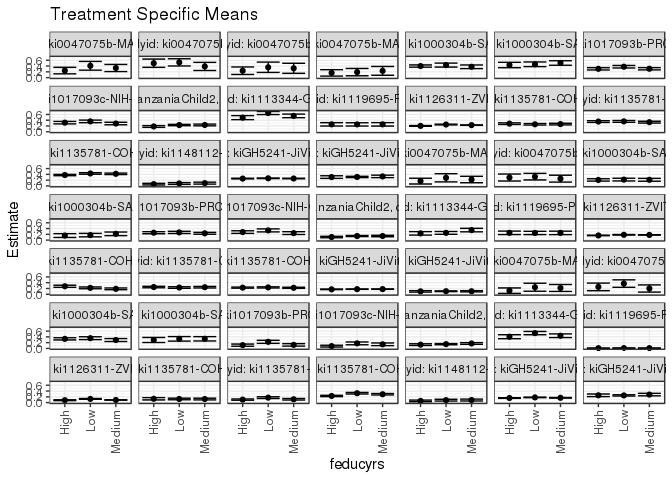

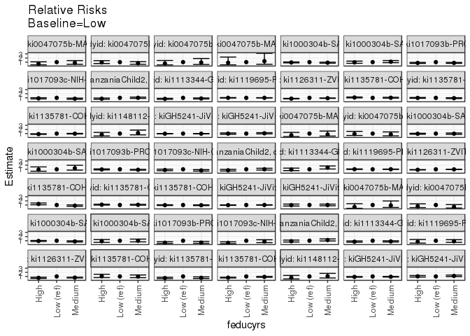

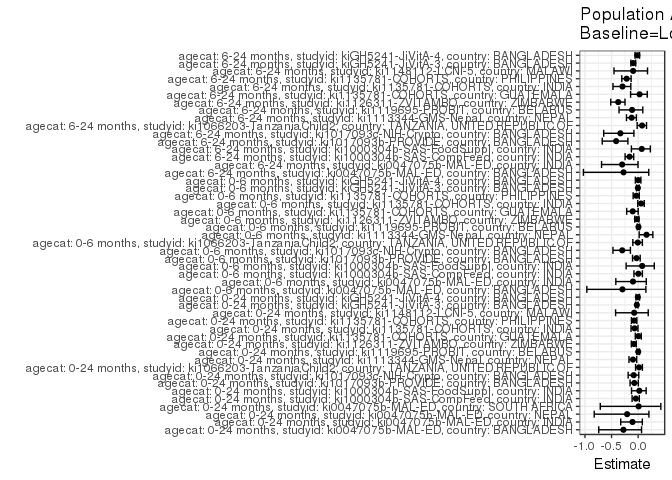

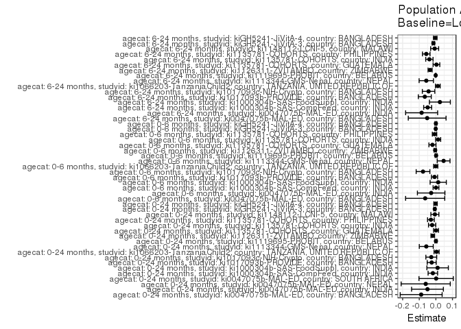

## Results Table

### Parameter: TSM

| agecat | studyid | country | intervention_level | baseline_level | estimate | ci_lower | ci_upper |
| --- | --- | --- | --- | --- | --- | --- | --- |
| 0-24 months | ki0047075b-MAL-ED | BANGLADESH | Low | NA | 0.4082019 | 0.2571604 | 0.5592433 |
| 0-24 months | ki0047075b-MAL-ED | BANGLADESH | Medium | NA | 0.3323576 | 0.2089221 | 0.4557930 |
| 0-24 months | ki0047075b-MAL-ED | BANGLADESH | High | NA | 0.2433164 | 0.1311910 | 0.3554417 |
| 0-24 months | ki0047075b-MAL-ED | INDIA | Low | NA | 0.5267012 | 0.4019036 | 0.6514988 |
| 0-24 months | ki0047075b-MAL-ED | INDIA | Medium | NA | 0.3861494 | 0.2459810 | 0.5263177 |
| 0-24 months | ki0047075b-MAL-ED | INDIA | High | NA | 0.4980189 | 0.3553284 | 0.6407094 |
| 0-24 months | ki0047075b-MAL-ED | NEPAL | Low | NA | 0.3571429 | 0.1787512 | 0.5355345 |
| 0-24 months | ki0047075b-MAL-ED | NEPAL | Medium | NA | 0.3214286 | 0.1475539 | 0.4953032 |
| 0-24 months | ki0047075b-MAL-ED | NEPAL | High | NA | 0.2380952 | 0.1086231 | 0.3675674 |
| 0-24 months | ki0047075b-MAL-ED | SOUTH AFRICA | Low | NA | 0.1891892 | 0.0624128 | 0.3159655 |
| 0-24 months | ki0047075b-MAL-ED | SOUTH AFRICA | Medium | NA | 0.2333333 | 0.0812918 | 0.3853749 |
| 0-24 months | ki0047075b-MAL-ED | SOUTH AFRICA | High | NA | 0.1627907 | 0.0519425 | 0.2736389 |
| 0-24 months | ki1000304b-SAS-CompFeed | INDIA | Low | NA | 0.4326920 | 0.3643376 | 0.5010464 |
| 0-24 months | ki1000304b-SAS-CompFeed | INDIA | Medium | NA | 0.3740554 | 0.3114981 | 0.4366127 |
| 0-24 months | ki1000304b-SAS-CompFeed | INDIA | High | NA | 0.3992675 | 0.3605521 | 0.4379828 |
| 0-24 months | ki1000304b-SAS-FoodSuppl | INDIA | Low | NA | 0.4607485 | 0.3804330 | 0.5410641 |
| 0-24 months | ki1000304b-SAS-FoodSuppl | INDIA | Medium | NA | 0.5046652 | 0.4277513 | 0.5815791 |
| 0-24 months | ki1000304b-SAS-FoodSuppl | INDIA | High | NA | 0.4365624 | 0.3437809 | 0.5293438 |
| 0-24 months | ki1017093b-PROVIDE | BANGLADESH | Low | NA | 0.3764888 | 0.3331096 | 0.4198680 |
| 0-24 months | ki1017093b-PROVIDE | BANGLADESH | Medium | NA | 0.3056078 | 0.2662148 | 0.3450009 |
| 0-24 months | ki1017093b-PROVIDE | BANGLADESH | High | NA | 0.3037064 | 0.2634606 | 0.3439523 |
| 0-24 months | ki1017093c-NIH-Crypto | BANGLADESH | Low | NA | 0.3587688 | 0.3145278 | 0.4030098 |
| 0-24 months | ki1017093c-NIH-Crypto | BANGLADESH | Medium | NA | 0.2852390 | 0.2415664 | 0.3289117 |
| 0-24 months | ki1017093c-NIH-Crypto | BANGLADESH | High | NA | 0.3151590 | 0.2730005 | 0.3573175 |
| 0-24 months | ki1066203-TanzaniaChild2 | TANZANIA, UNITED REPUBLIC OF | Low | NA | 0.2324247 | 0.2099833 | 0.2548662 |
| 0-24 months | ki1066203-TanzaniaChild2 | TANZANIA, UNITED REPUBLIC OF | Medium | NA | 0.2357770 | 0.2060386 | 0.2655154 |
| 0-24 months | ki1066203-TanzaniaChild2 | TANZANIA, UNITED REPUBLIC OF | High | NA | 0.1840865 | 0.1532754 | 0.2148975 |
| 0-24 months | ki1113344-GMS-Nepal | NEPAL | Low | NA | 0.6484656 | 0.5953426 | 0.7015886 |
| 0-24 months | ki1113344-GMS-Nepal | NEPAL | Medium | NA | 0.5486216 | 0.4859745 | 0.6112686 |
| 0-24 months | ki1113344-GMS-Nepal | NEPAL | High | NA | 0.4884132 | 0.4195011 | 0.5573252 |

[output cut: 117 more lines]

### Parameter: E(Y)

| agecat | studyid | country | intervention_level | baseline_level | estimate | ci_lower | ci_upper |
| --- | --- | --- | --- | --- | --- | --- | --- |
| 0-24 months | ki0047075b-MAL-ED | BANGLADESH | NA | NA | 0.3197279 | 0.2440789 | 0.3953769 |
| 0-24 months | ki0047075b-MAL-ED | INDIA | NA | NA | 0.4761905 | 0.3951786 | 0.5572024 |
| 0-24 months | ki0047075b-MAL-ED | NEPAL | NA | NA | 0.2959184 | 0.2050820 | 0.3867547 |
| 0-24 months | ki0047075b-MAL-ED | SOUTH AFRICA | NA | NA | 0.1909091 | 0.1171277 | 0.2646905 |
| 0-24 months | ki1000304b-SAS-CompFeed | INDIA | NA | NA | 0.4145695 | 0.3576236 | 0.4715155 |
| 0-24 months | ki1000304b-SAS-FoodSuppl | INDIA | NA | NA | 0.4712919 | 0.4233811 | 0.5192026 |
| 0-24 months | ki1017093b-PROVIDE | BANGLADESH | NA | NA | 0.3514286 | 0.3160364 | 0.3868207 |
| 0-24 months | ki1017093c-NIH-Crypto | BANGLADESH | NA | NA | 0.3311346 | 0.2976093 | 0.3646598 |
| 0-24 months | ki1066203-TanzaniaChild2 | TANZANIA, UNITED REPUBLIC OF | NA | NA | 0.2366765 | 0.2196074 | 0.2537455 |
| 0-24 months | ki1113344-GMS-Nepal | NEPAL | NA | NA | 0.5906822 | 0.5513381 | 0.6300263 |
| 0-24 months | ki1119695-PROBIT | BELARUS | NA | NA | 0.2556543 | 0.1980936 | 0.3132150 |
| 0-24 months | ki1126311-ZVITAMBO | ZIMBABWE | NA | NA | 0.2317505 | 0.2246488 | 0.2388522 |
| 0-24 months | ki1135781-COHORTS | GUATEMALA | NA | NA | 0.2601297 | 0.2356425 | 0.2846169 |
| 0-24 months | ki1135781-COHORTS | INDIA | NA | NA | 0.3365584 | 0.3122030 | 0.3609138 |
| 0-24 months | ki1135781-COHORTS | PHILIPPINES | NA | NA | 0.4013250 | 0.3833827 | 0.4192673 |
| 0-24 months | ki1148112-LCNI-5 | MALAWI | NA | NA | 0.0799508 | 0.0612962 | 0.0986054 |
| 0-24 months | kiGH5241-JiVitA-3 | BANGLADESH | NA | NA | 0.2575635 | 0.2509808 | 0.2641462 |
| 0-24 months | kiGH5241-JiVitA-4 | BANGLADESH | NA | NA | 0.3085018 | 0.2890487 | 0.3279548 |
| 0-6 months | ki0047075b-MAL-ED | BANGLADESH | NA | NA | 0.2176871 | 0.1507482 | 0.2846259 |
| 0-6 months | ki0047075b-MAL-ED | INDIA | NA | NA | 0.2925170 | 0.2187257 | 0.3663083 |
| 0-6 months | ki1000304b-SAS-CompFeed | INDIA | NA | NA | 0.2197071 | 0.1750081 | 0.2644060 |
| 0-6 months | ki1000304b-SAS-FoodSuppl | INDIA | NA | NA | 0.1866029 | 0.1492099 | 0.2239959 |
| 0-6 months | ki1017093b-PROVIDE | BANGLADESH | NA | NA | 0.2585714 | 0.2261125 | 0.2910304 |
| 0-6 months | ki1017093c-NIH-Crypto | BANGLADESH | NA | NA | 0.2585752 | 0.2273844 | 0.2897660 |
| 0-6 months | ki1066203-TanzaniaChild2 | TANZANIA, UNITED REPUBLIC OF | NA | NA | 0.1397398 | 0.1258162 | 0.1536634 |
| 0-6 months | ki1113344-GMS-Nepal | NEPAL | NA | NA | 0.2961730 | 0.2596406 | 0.3327054 |
| 0-6 months | ki1119695-PROBIT | BELARUS | NA | NA | 0.2487739 | 0.1904535 | 0.3070943 |
| 0-6 months | ki1126311-ZVITAMBO | ZIMBABWE | NA | NA | 0.1794091 | 0.1729298 | 0.1858885 |
| 0-6 months | ki1135781-COHORTS | GUATEMALA | NA | NA | 0.2006018 | 0.1757323 | 0.2254713 |
| 0-6 months | ki1135781-COHORTS | INDIA | NA | NA | 0.2462950 | 0.2238538 | 0.2687361 |
| 0-6 months | ki1135781-COHORTS | PHILIPPINES | NA | NA | 0.2291594 | 0.2137721 | 0.2445467 |
| 0-6 months | kiGH5241-JiVitA-3 | BANGLADESH | NA | NA | 0.1758866 | 0.1701478 | 0.1816254 |
| 0-6 months | kiGH5241-JiVitA-4 | BANGLADESH | NA | NA | 0.1055729 | 0.0925062 | 0.1186395 |
| 6-24 months | ki0047075b-MAL-ED | BANGLADESH | NA | NA | 0.1908397 | 0.1232893 | 0.2583901 |
| 6-24 months | ki0047075b-MAL-ED | INDIA | NA | NA | 0.2846715 | 0.2088306 | 0.3605124 |
| 6-24 months | ki1000304b-SAS-CompFeed | INDIA | NA | NA | 0.3051948 | 0.2633957 | 0.3469939 |
| 6-24 months | ki1000304b-SAS-FoodSuppl | INDIA | NA | NA | 0.3557214 | 0.3088651 | 0.4025777 |
| 6-24 months | ki1017093b-PROVIDE | BANGLADESH | NA | NA | 0.1609756 | 0.1319065 | 0.1900447 |
| 6-24 months | ki1017093c-NIH-Crypto | BANGLADESH | NA | NA | 0.1315068 | 0.1069744 | 0.1560393 |
| 6-24 months | ki1066203-TanzaniaChild2 | TANZANIA, UNITED REPUBLIC OF | NA | NA | 0.1602787 | 0.1442326 | 0.1763249 |
| 6-24 months | ki1113344-GMS-Nepal | NEPAL | NA | NA | 0.4719864 | 0.4316361 | 0.5123367 |
| 6-24 months | ki1119695-PROBIT | BELARUS | NA | NA | 0.0102327 | 0.0075781 | 0.0128874 |
| 6-24 months | ki1126311-ZVITAMBO | ZIMBABWE | NA | NA | 0.0926247 | 0.0870490 | 0.0982004 |
| 6-24 months | ki1135781-COHORTS | GUATEMALA | NA | NA | 0.1288889 | 0.1093000 | 0.1484778 |
| 6-24 months | ki1135781-COHORTS | INDIA | NA | NA | 0.1323843 | 0.1146569 | 0.1501118 |
| 6-24 months | ki1135781-COHORTS | PHILIPPINES | NA | NA | 0.2666667 | 0.2498425 | 0.2834908 |
| 6-24 months | ki1148112-LCNI-5 | MALAWI | NA | NA | 0.0773067 | 0.0588111 | 0.0958024 |
| 6-24 months | kiGH5241-JiVitA-3 | BANGLADESH | NA | NA | 0.1644249 | 0.1581893 | 0.1706604 |
| 6-24 months | kiGH5241-JiVitA-4 | BANGLADESH | NA | NA | 0.2442659 | 0.2256986 | 0.2628332 |

### Parameter: RR

| agecat | studyid | country | intervention_level | baseline_level | estimate | ci_lower | ci_upper |
| --- | --- | --- | --- | --- | --- | --- | --- |
| 0-24 months | ki0047075b-MAL-ED | BANGLADESH | Low | Low | 1.0000000 | 1.0000000 | 1.0000000 |
| 0-24 months | ki0047075b-MAL-ED | BANGLADESH | Medium | Low | 0.8141990 | 0.4841124 | 1.3693515 |
| 0-24 months | ki0047075b-MAL-ED | BANGLADESH | High | Low | 0.5960687 | 0.3315284 | 1.0716966 |
| 0-24 months | ki0047075b-MAL-ED | INDIA | Low | Low | 1.0000000 | 1.0000000 | 1.0000000 |
| 0-24 months | ki0047075b-MAL-ED | INDIA | Medium | Low | 0.7331469 | 0.4765381 | 1.1279358 |
| 0-24 months | ki0047075b-MAL-ED | INDIA | High | Low | 0.9455435 | 0.6546150 | 1.3657685 |
| 0-24 months | ki0047075b-MAL-ED | NEPAL | Low | Low | 1.0000000 | 1.0000000 | 1.0000000 |
| 0-24 months | ki0047075b-MAL-ED | NEPAL | Medium | Low | 0.9000000 | 0.4310005 | 1.8793484 |
| 0-24 months | ki0047075b-MAL-ED | NEPAL | High | Low | 0.6666667 | 0.3185934 | 1.3950207 |
| 0-24 months | ki0047075b-MAL-ED | SOUTH AFRICA | Low | Low | 1.0000000 | 1.0000000 | 1.0000000 |
| 0-24 months | ki0047075b-MAL-ED | SOUTH AFRICA | Medium | Low | 1.2333333 | 0.4843434 | 3.1405635 |
| 0-24 months | ki0047075b-MAL-ED | SOUTH AFRICA | High | Low | 0.8604651 | 0.3310009 | 2.2368526 |
| 0-24 months | ki1000304b-SAS-CompFeed | INDIA | Low | Low | 1.0000000 | 1.0000000 | 1.0000000 |
| 0-24 months | ki1000304b-SAS-CompFeed | INDIA | Medium | Low | 0.8644842 | 0.7544288 | 0.9905944 |
| 0-24 months | ki1000304b-SAS-CompFeed | INDIA | High | Low | 0.9227521 | 0.8165771 | 1.0427325 |
| 0-24 months | ki1000304b-SAS-FoodSuppl | INDIA | Low | Low | 1.0000000 | 1.0000000 | 1.0000000 |
| 0-24 months | ki1000304b-SAS-FoodSuppl | INDIA | Medium | Low | 1.0953159 | 0.8695055 | 1.3797690 |
| 0-24 months | ki1000304b-SAS-FoodSuppl | INDIA | High | Low | 0.9475069 | 0.7200159 | 1.2468742 |
| 0-24 months | ki1017093b-PROVIDE | BANGLADESH | Low | Low | 1.0000000 | 1.0000000 | 1.0000000 |
| 0-24 months | ki1017093b-PROVIDE | BANGLADESH | Medium | Low | 0.8117316 | 0.7099208 | 0.9281431 |
| 0-24 months | ki1017093b-PROVIDE | BANGLADESH | High | Low | 0.8066812 | 0.7007871 | 0.9285767 |
| 0-24 months | ki1017093c-NIH-Crypto | BANGLADESH | Low | Low | 1.0000000 | 1.0000000 | 1.0000000 |
| 0-24 months | ki1017093c-NIH-Crypto | BANGLADESH | Medium | Low | 0.7950497 | 0.6686826 | 0.9452976 |
| 0-24 months | ki1017093c-NIH-Crypto | BANGLADESH | High | Low | 0.8784459 | 0.7479626 | 1.0316921 |
| 0-24 months | ki1066203-TanzaniaChild2 | TANZANIA, UNITED REPUBLIC OF | Low | Low | 1.0000000 | 1.0000000 | 1.0000000 |
| 0-24 months | ki1066203-TanzaniaChild2 | TANZANIA, UNITED REPUBLIC OF | Medium | Low | 1.0144230 | 0.8660501 | 1.1882155 |
| 0-24 months | ki1066203-TanzaniaChild2 | TANZANIA, UNITED REPUBLIC OF | High | Low | 0.7920262 | 0.6533798 | 0.9600931 |
| 0-24 months | ki1113344-GMS-Nepal | NEPAL | Low | Low | 1.0000000 | 1.0000000 | 1.0000000 |
| 0-24 months | ki1113344-GMS-Nepal | NEPAL | Medium | Low | 0.8460303 | 0.7351272 | 0.9736646 |
| 0-24 months | ki1113344-GMS-Nepal | NEPAL | High | Low | 0.7531828 | 0.6397018 | 0.8867950 |

[output cut: 117 more lines]

### Parameter: PAR

| agecat | studyid | country | intervention_level | baseline_level | estimate | ci_lower | ci_upper |
| --- | --- | --- | --- | --- | --- | --- | --- |
| 0-24 months | ki0047075b-MAL-ED | BANGLADESH | Low | NA | -0.0884740 | -0.2146688 | 0.0377209 |
| 0-24 months | ki0047075b-MAL-ED | INDIA | Low | NA | -0.0505107 | -0.1462066 | 0.0451852 |
| 0-24 months | ki0047075b-MAL-ED | NEPAL | Low | NA | -0.0612245 | -0.2091769 | 0.0867279 |
| 0-24 months | ki0047075b-MAL-ED | SOUTH AFRICA | Low | NA | 0.0017199 | -0.1017388 | 0.1051786 |
| 0-24 months | ki1000304b-SAS-CompFeed | INDIA | Low | NA | -0.0181225 | -0.0467349 | 0.0104899 |
| 0-24 months | ki1000304b-SAS-FoodSuppl | INDIA | Low | NA | 0.0105433 | -0.0540525 | 0.0751391 |
| 0-24 months | ki1017093b-PROVIDE | BANGLADESH | Low | NA | -0.0250602 | -0.0521423 | 0.0020219 |
| 0-24 months | ki1017093c-NIH-Crypto | BANGLADESH | Low | NA | -0.0276342 | -0.0602625 | 0.0049940 |
| 0-24 months | ki1066203-TanzaniaChild2 | TANZANIA, UNITED REPUBLIC OF | Low | NA | 0.0042517 | -0.0109778 | 0.0194813 |
| 0-24 months | ki1113344-GMS-Nepal | NEPAL | Low | NA | -0.0577834 | -0.0998105 | -0.0157564 |
| 0-24 months | ki1119695-PROBIT | BELARUS | Low | NA | 0.0003669 | -0.0057527 | 0.0064864 |
| 0-24 months | ki1126311-ZVITAMBO | ZIMBABWE | Low | NA | -0.0185704 | -0.0292981 | -0.0078428 |
| 0-24 months | ki1135781-COHORTS | GUATEMALA | Low | NA | 0.0011013 | -0.0136312 | 0.0158338 |
| 0-24 months | ki1135781-COHORTS | INDIA | Low | NA | -0.0224513 | -0.0441848 | -0.0007177 |
| 0-24 months | ki1135781-COHORTS | PHILIPPINES | Low | NA | -0.0298864 | -0.0500312 | -0.0097416 |
| 0-24 months | ki1148112-LCNI-5 | MALAWI | Low | NA | -0.0059475 | -0.0301063 | 0.0182113 |
| 0-24 months | kiGH5241-JiVitA-3 | BANGLADESH | Low | NA | -0.0063796 | -0.0123856 | -0.0003736 |
| 0-24 months | kiGH5241-JiVitA-4 | BANGLADESH | Low | NA | -0.0019904 | -0.0122729 | 0.0082921 |
| 0-6 months | ki0047075b-MAL-ED | BANGLADESH | Low | NA | -0.0643642 | -0.1822934 | 0.0535649 |
| 0-6 months | ki0047075b-MAL-ED | INDIA | Low | NA | -0.0283401 | -0.1111786 | 0.0544985 |
| 0-6 months | ki1000304b-SAS-CompFeed | INDIA | Low | NA | 0.0008070 | -0.0166527 | 0.0182666 |
| 0-6 months | ki1000304b-SAS-FoodSuppl | INDIA | Low | NA | 0.0141378 | -0.0346495 | 0.0629251 |
| 0-6 months | ki1017093b-PROVIDE | BANGLADESH | Low | NA | -0.0081012 | -0.0266201 | 0.0104177 |
| 0-6 months | ki1017093c-NIH-Crypto | BANGLADESH | Low | NA | -0.0773900 | -0.1187088 | -0.0360711 |
| 0-6 months | ki1066203-TanzaniaChild2 | TANZANIA, UNITED REPUBLIC OF | Low | NA | -0.0008848 | -0.0133974 | 0.0116278 |
| 0-6 months | ki1113344-GMS-Nepal | NEPAL | Low | NA | 0.0466925 | 0.0081882 | 0.0851968 |
| 0-6 months | ki1119695-PROBIT | BELARUS | Low | NA | 0.0014827 | -0.0042920 | 0.0072574 |
| 0-6 months | ki1126311-ZVITAMBO | ZIMBABWE | Low | NA | -0.0042140 | -0.0112194 | 0.0027914 |
| 0-6 months | ki1135781-COHORTS | GUATEMALA | Low | NA | -0.0205592 | -0.0417143 | 0.0005959 |
| 0-6 months | ki1135781-COHORTS | INDIA | Low | NA | 0.0137314 | -0.0014894 | 0.0289521 |
| 0-6 months | ki1135781-COHORTS | PHILIPPINES | Low | NA | -0.0079803 | -0.0211949 | 0.0052343 |
| 0-6 months | kiGH5241-JiVitA-3 | BANGLADESH | Low | NA | -0.0008845 | -0.0053037 | 0.0035346 |
| 0-6 months | kiGH5241-JiVitA-4 | BANGLADESH | Low | NA | 0.0000686 | -0.0054361 | 0.0055733 |
| 6-24 months | ki0047075b-MAL-ED | BANGLADESH | Low | NA | -0.0524035 | -0.1661693 | 0.0613622 |
| 6-24 months | ki0047075b-MAL-ED | INDIA | Low | NA | -0.0856988 | -0.1820795 | 0.0106818 |
| 6-24 months | ki1000304b-SAS-CompFeed | INDIA | Low | NA | -0.0494280 | -0.0733981 | -0.0254578 |
| 6-24 months | ki1000304b-SAS-FoodSuppl | INDIA | Low | NA | 0.0242175 | -0.0387583 | 0.0871932 |
| 6-24 months | ki1017093b-PROVIDE | BANGLADESH | Low | NA | -0.0666242 | -0.1055815 | -0.0276668 |
| 6-24 months | ki1017093c-NIH-Crypto | BANGLADESH | Low | NA | -0.0439464 | -0.0815032 | -0.0063897 |
| 6-24 months | ki1066203-TanzaniaChild2 | TANZANIA, UNITED REPUBLIC OF | Low | NA | 0.0117782 | -0.0023810 | 0.0259374 |
| 6-24 months | ki1113344-GMS-Nepal | NEPAL | Low | NA | -0.0577829 | -0.1008776 | -0.0146883 |
| 6-24 months | ki1119695-PROBIT | BELARUS | Low | NA | -0.0011648 | -0.0035358 | 0.0012062 |
| 6-24 months | ki1126311-ZVITAMBO | ZIMBABWE | Low | NA | -0.0347401 | -0.0469980 | -0.0224823 |
| 6-24 months | ki1135781-COHORTS | GUATEMALA | Low | NA | 0.0034969 | -0.0166158 | 0.0236096 |
| 6-24 months | ki1135781-COHORTS | INDIA | Low | NA | -0.0390230 | -0.0610654 | -0.0169805 |
| 6-24 months | ki1135781-COHORTS | PHILIPPINES | Low | NA | -0.0578094 | -0.0805764 | -0.0350424 |
| 6-24 months | ki1148112-LCNI-5 | MALAWI | Low | NA | -0.0073132 | -0.0313402 | 0.0167137 |
| 6-24 months | kiGH5241-JiVitA-3 | BANGLADESH | Low | NA | -0.0149344 | -0.0223522 | -0.0075166 |
| 6-24 months | kiGH5241-JiVitA-4 | BANGLADESH | Low | NA | -0.0036835 | -0.0141639 | 0.0067969 |

### Parameter: PAF

| agecat | studyid | country | intervention_level | baseline_level | estimate | ci_lower | ci_upper |
| --- | --- | --- | --- | --- | --- | --- | --- |
| 0-24 months | ki0047075b-MAL-ED | BANGLADESH | Low | NA | -0.2767164 | -0.7411752 | 0.0638479 |
| 0-24 months | ki0047075b-MAL-ED | INDIA | Low | NA | -0.1060725 | -0.3276213 | 0.0785050 |
| 0-24 months | ki0047075b-MAL-ED | NEPAL | Low | NA | -0.2068966 | -0.8264376 | 0.2024916 |
| 0-24 months | ki0047075b-MAL-ED | SOUTH AFRICA | Low | NA | 0.0090090 | -0.7122310 | 0.4264424 |
| 0-24 months | ki1000304b-SAS-CompFeed | INDIA | Low | NA | -0.0437139 | -0.1141353 | 0.0222563 |
| 0-24 months | ki1000304b-SAS-FoodSuppl | INDIA | Low | NA | 0.0223712 | -0.1247773 | 0.1502690 |
| 0-24 months | ki1017093b-PROVIDE | BANGLADESH | Low | NA | -0.0713096 | -0.1519878 | 0.0037184 |
| 0-24 months | ki1017093c-NIH-Crypto | BANGLADESH | Low | NA | -0.0834532 | -0.1879747 | 0.0118722 |
| 0-24 months | ki1066203-TanzaniaChild2 | TANZANIA, UNITED REPUBLIC OF | Low | NA | 0.0179642 | -0.0484999 | 0.0802152 |
| 0-24 months | ki1113344-GMS-Nepal | NEPAL | Low | NA | -0.0978249 | -0.1726731 | -0.0277540 |
| 0-24 months | ki1119695-PROBIT | BELARUS | Low | NA | 0.0014350 | -0.0226996 | 0.0250000 |
| 0-24 months | ki1126311-ZVITAMBO | ZIMBABWE | Low | NA | -0.0801312 | -0.1275160 | -0.0347378 |
| 0-24 months | ki1135781-COHORTS | GUATEMALA | Low | NA | 0.0042336 | -0.0539570 | 0.0592114 |
| 0-24 months | ki1135781-COHORTS | INDIA | Low | NA | -0.0667084 | -0.1338545 | -0.0035386 |
| 0-24 months | ki1135781-COHORTS | PHILIPPINES | Low | NA | -0.0744693 | -0.1263328 | -0.0249939 |
| 0-24 months | ki1148112-LCNI-5 | MALAWI | Low | NA | -0.0743891 | -0.4242578 | 0.1895344 |
| 0-24 months | kiGH5241-JiVitA-3 | BANGLADESH | Low | NA | -0.0247689 | -0.0483948 | -0.0016754 |
| 0-24 months | kiGH5241-JiVitA-4 | BANGLADESH | Low | NA | -0.0064518 | -0.0403229 | 0.0263166 |
| 0-6 months | ki0047075b-MAL-ED | BANGLADESH | Low | NA | -0.2956731 | -0.9650094 | 0.1456689 |
| 0-6 months | ki0047075b-MAL-ED | INDIA | Low | NA | -0.0968835 | -0.4200044 | 0.1527115 |
| 0-6 months | ki1000304b-SAS-CompFeed | INDIA | Low | NA | 0.0036729 | -0.0790052 | 0.0800159 |
| 0-6 months | ki1000304b-SAS-FoodSuppl | INDIA | Low | NA | 0.0757640 | -0.2258573 | 0.3031716 |
| 0-6 months | ki1017093b-PROVIDE | BANGLADESH | Low | NA | -0.0313308 | -0.1056749 | 0.0380146 |
| 0-6 months | ki1017093c-NIH-Crypto | BANGLADESH | Low | NA | -0.2992938 | -0.4737356 | -0.1455002 |
| 0-6 months | ki1066203-TanzaniaChild2 | TANZANIA, UNITED REPUBLIC OF | Low | NA | -0.0063315 | -0.0999916 | 0.0793537 |
| 0-6 months | ki1113344-GMS-Nepal | NEPAL | Low | NA | 0.1576527 | 0.0191237 | 0.2766173 |
| 0-6 months | ki1119695-PROBIT | BELARUS | Low | NA | 0.0059601 | -0.0171820 | 0.0285757 |
| 0-6 months | ki1126311-ZVITAMBO | ZIMBABWE | Low | NA | -0.0234881 | -0.0633127 | 0.0148449 |
| 0-6 months | ki1135781-COHORTS | GUATEMALA | Low | NA | -0.1024877 | -0.2158060 | 0.0002688 |
| 0-6 months | ki1135781-COHORTS | INDIA | Low | NA | 0.0557517 | -0.0076893 | 0.1151986 |
| 0-6 months | ki1135781-COHORTS | PHILIPPINES | Low | NA | -0.0348243 | -0.0943745 | 0.0214855 |
| 0-6 months | kiGH5241-JiVitA-3 | BANGLADESH | Low | NA | -0.0050291 | -0.0304828 | 0.0197960 |
| 0-6 months | kiGH5241-JiVitA-4 | BANGLADESH | Low | NA | 0.0006499 | -0.0528706 | 0.0514498 |
| 6-24 months | ki0047075b-MAL-ED | BANGLADESH | Low | NA | -0.2745946 | -1.0296154 | 0.1995570 |
| 6-24 months | ki0047075b-MAL-ED | INDIA | Low | NA | -0.3010446 | -0.6881859 | -0.0026841 |
| 6-24 months | ki1000304b-SAS-CompFeed | INDIA | Low | NA | -0.1619555 | -0.2455558 | -0.0839664 |
| 6-24 months | ki1000304b-SAS-FoodSuppl | INDIA | Low | NA | 0.0680799 | -0.1270834 | 0.2294491 |
| 6-24 months | ki1017093b-PROVIDE | BANGLADESH | Low | NA | -0.4138774 | -0.6754565 | -0.1931372 |
| 6-24 months | ki1017093c-NIH-Crypto | BANGLADESH | Low | NA | -0.3341761 | -0.6481839 | -0.0799922 |
| 6-24 months | ki1066203-TanzaniaChild2 | TANZANIA, UNITED REPUBLIC OF | Low | NA | 0.0734857 | -0.0188827 | 0.1574803 |
| 6-24 months | ki1113344-GMS-Nepal | NEPAL | Low | NA | -0.1224250 | -0.2191811 | -0.0333476 |
| 6-24 months | ki1119695-PROBIT | BELARUS | Low | NA | -0.1138305 | -0.3593475 | 0.0873427 |
| 6-24 months | ki1126311-ZVITAMBO | ZIMBABWE | Low | NA | -0.3750635 | -0.5159384 | -0.2472799 |
| 6-24 months | ki1135781-COHORTS | GUATEMALA | Low | NA | 0.0271309 | -0.1418970 | 0.1711386 |
| 6-24 months | ki1135781-COHORTS | INDIA | Low | NA | -0.2947701 | -0.4735760 | -0.1376609 |
| 6-24 months | ki1135781-COHORTS | PHILIPPINES | Low | NA | -0.2167852 | -0.3074791 | -0.1323823 |
| 6-24 months | ki1148112-LCNI-5 | MALAWI | Low | NA | -0.0946002 | -0.4545506 | 0.1762750 |
| 6-24 months | kiGH5241-JiVitA-3 | BANGLADESH | Low | NA | -0.0908280 | -0.1369962 | -0.0465345 |
| 6-24 months | kiGH5241-JiVitA-4 | BANGLADESH | Low | NA | -0.0150798 | -0.0588829 | 0.0269112 |